# Ch18Practice

Justine

2021/7/3

# Home

### 是非題

1.(O)barplot()與pie()兩個函數主要是用來繪製類別資料統計圖  
2.(X)dotchart()與plot()兩個函數主要是用來繪製類別資料統計圖  
3.(O)設定函數barplot()的參數horiz=TRUE將會繪製水平式的長條圖  
4.(X)如果想要在單張頁面放置多張圖片，必須使用參數mfrow  
5.(O)如果想要設定在一張頁面有2列3欄共六張圖，可以用指令設定如下：  
> par(mfrow=c(2,3))

6.(O)Plot主要是繪製兩數量變數的散佈圖(scatter plot)，可以從中觀察出兩數值變數間的線性相關的性質  
當然plot也被用來繪製table、factor以及timeSeries等物件的繪圖，只是不同的物件時所定義出來的圖形也會有所不同  
7.(X)Plot僅用來繪製兩數量變數的散佈圖(scatter plot)，  
可以從中觀察出兩數值變數間的線性相關的性質，並無法使用來對應類別變數，繪製出箱型圖  
8.(O)直方圖的R基本預設指令為hist(x)  
9.(X)箱型圖的R基本預設指令為plot(x)  
10.(O)x與y散佈圖(scatter plot)的R指令為plot(x, y)  
11.(O)箱型圖的R基本預設指令為boxplot(x)  
12.(X)莖葉圖的R基本預設指令為stemplot(x)  
13.(O)長條圖的R基本預設指令為barplot(x)  
14.(O)莖葉圖的R基本預設指令為stem(x)

### 選擇題

1.(C)以下哪一個函數主要是用來繪製類別資料統計圖?  
(A)boxplot() (B)dotchart() (C)barplot() (D)hist()  
2.(A)以下哪一個函數主要是用來繪製數值資料統計圖?  
(A)boxplot() (B)pie() (C)barplot() (D)points()  
3.(D)以下哪一種類型的統計圖是plot()函數無法達成的?  
(A)成對的散佈圖 (B)時間序列圖  
(C)箱型比較圖 (D)所列三種都可以達成  
4.(D)當以下的指令被執行後，我們可以得到何種的統計圖形?  
> plot(as.factor(x))  
(A)散佈圖 (B)時間序列圖 (C)箱型圖 (D)長條圖

5.(D)使用哪一個函數可以建立一個最簡單的線性模型?  
(A)abline() (B)anova() (C)lines() (D)lm()  
8.(B)何組R指令會產生以下圖型?  
(A)

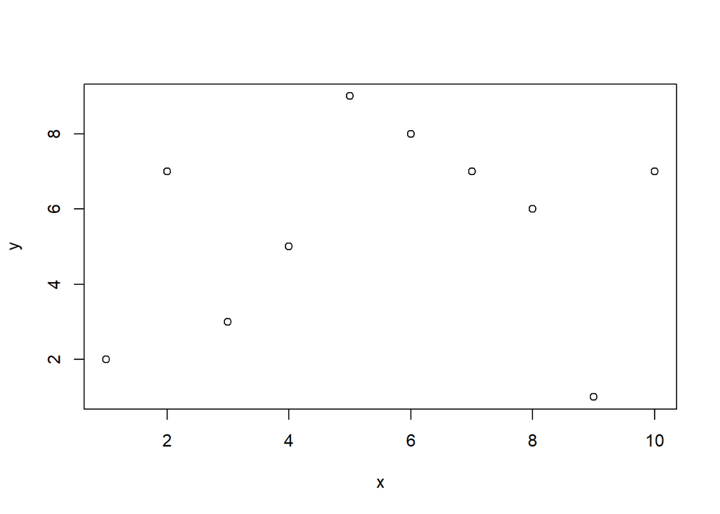

```r
x=1:10
y=c(2,7,3,5,9,8,7,6,1,7)
plot(x,y)
```

(B)

[output not shown]

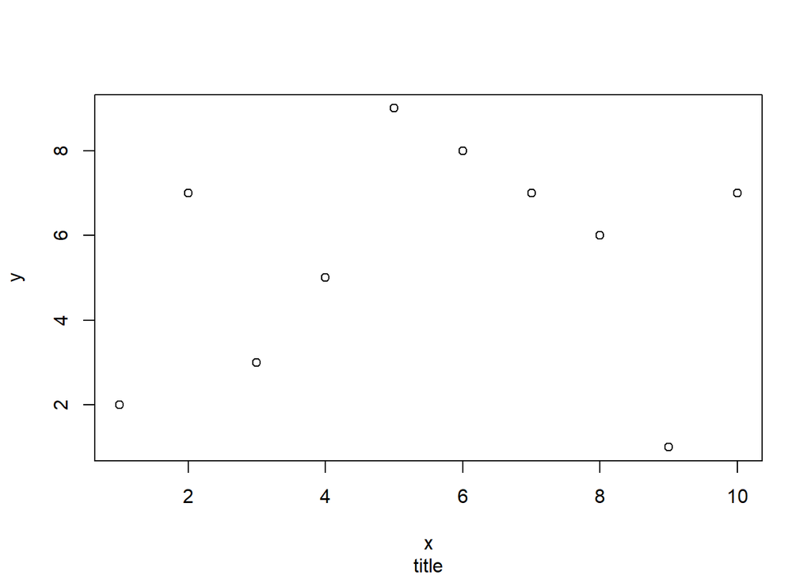

```r
x=1:10
y=c(2,7,3,5,9,8,7,6,1,7)
plot(x,y)
title(sub = "title")
```

(D)

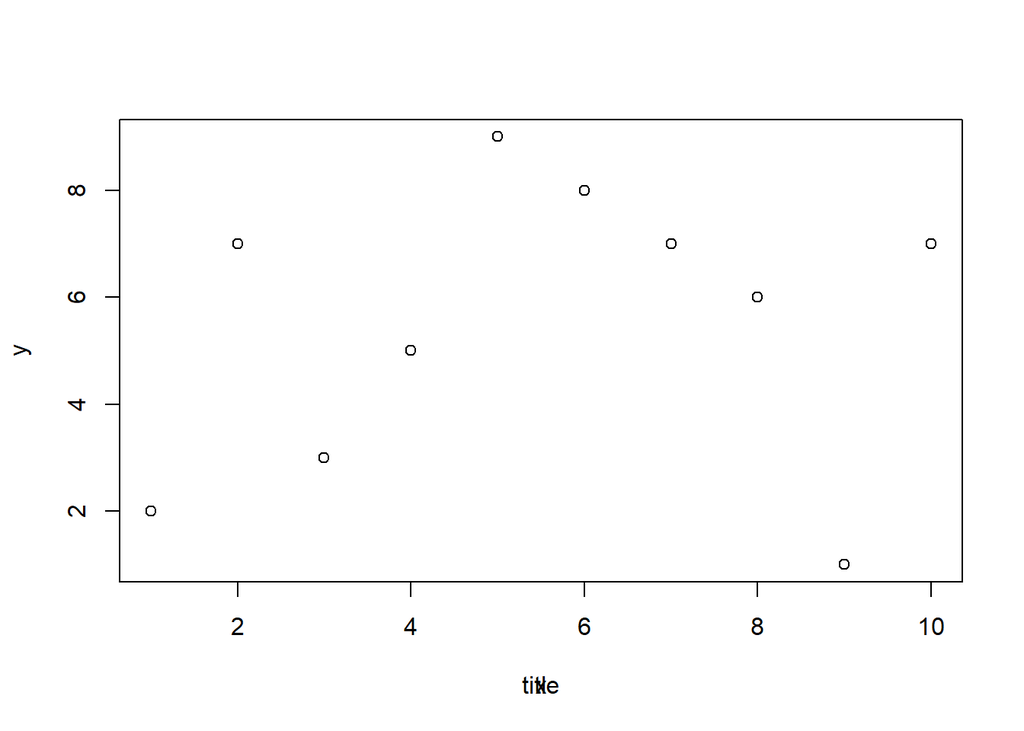

```r
x=1:10
y=c(2,7,3,5,9,8,7,6,1,7)
plot(x,y)
title(xlab = "title")
```

9.(B)何組R指令會產生以下圖型？  
(A)

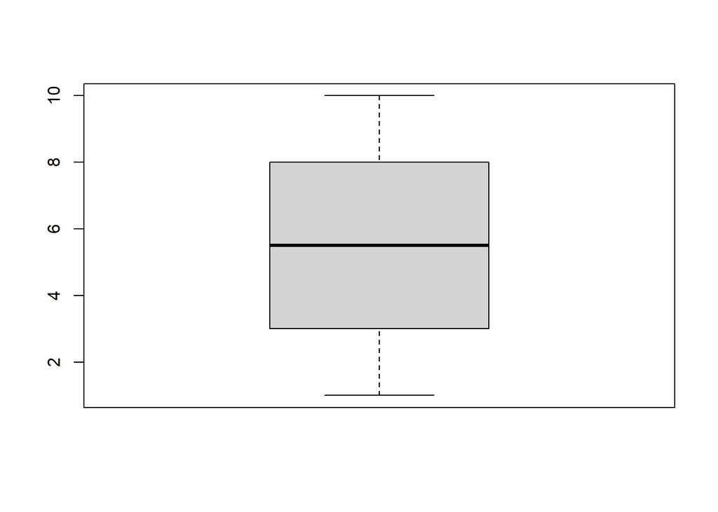

```r
boxplot(x)
```

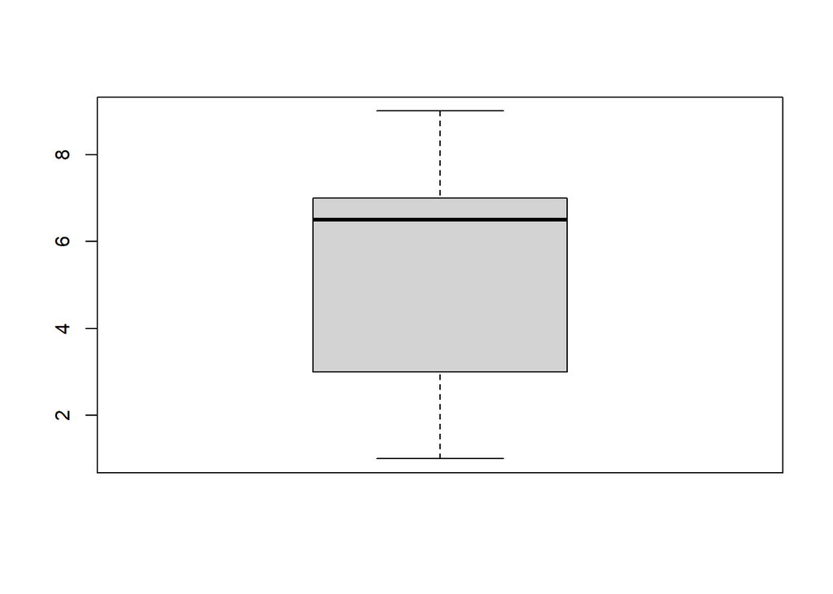

```r
boxplot(y)
```

```r
par(mfrow=c(1,2))
```

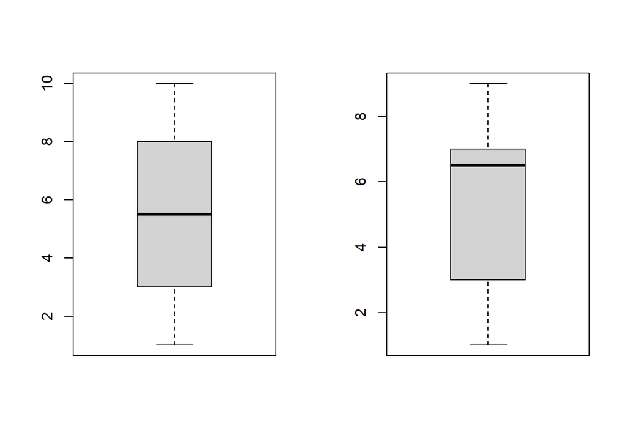

```r
par(mfrow=c(1,2))
boxplot(x)
boxplot(y)
```

(C)

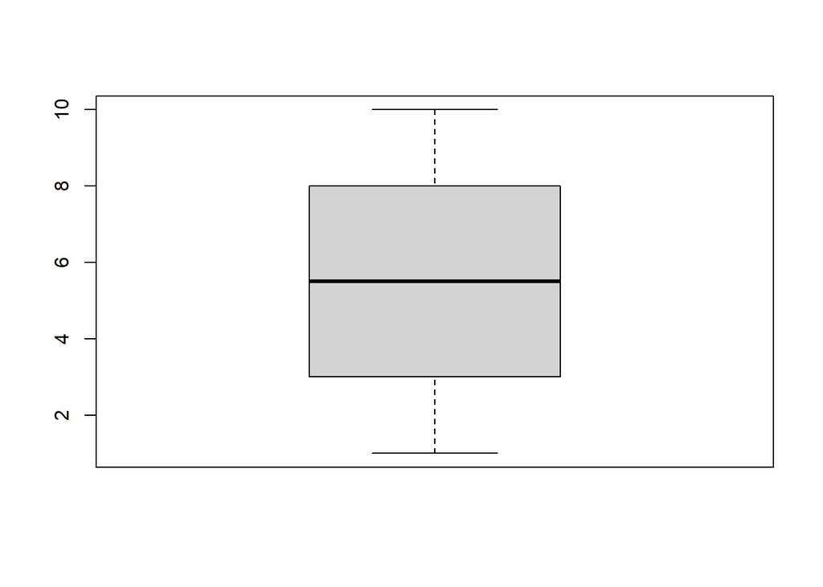

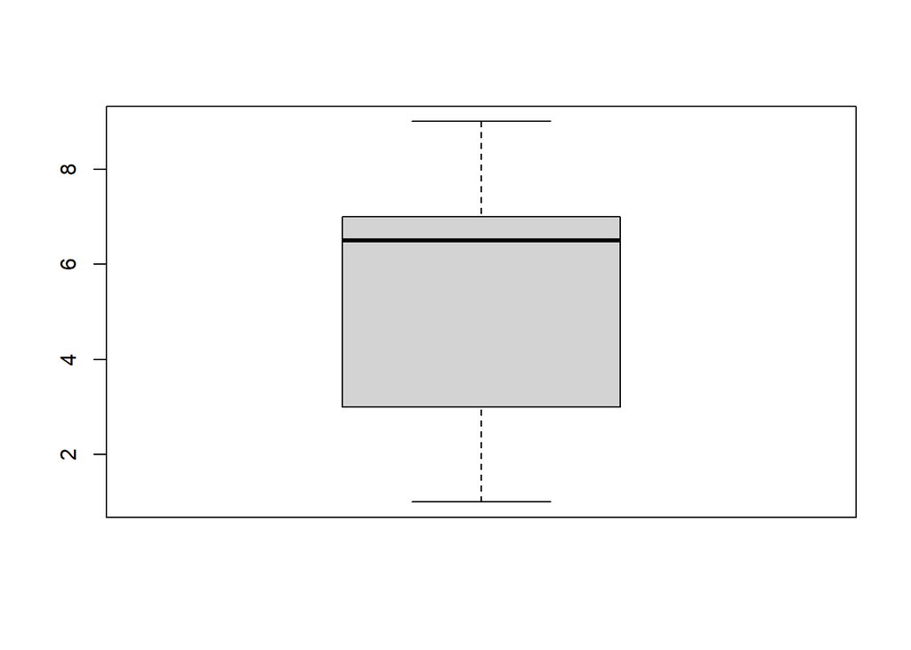

```r
par(mfrow=c(boxplot(x),boxplot(y)))
```

(D)以上皆非

10.(B)以下R指令結果為?

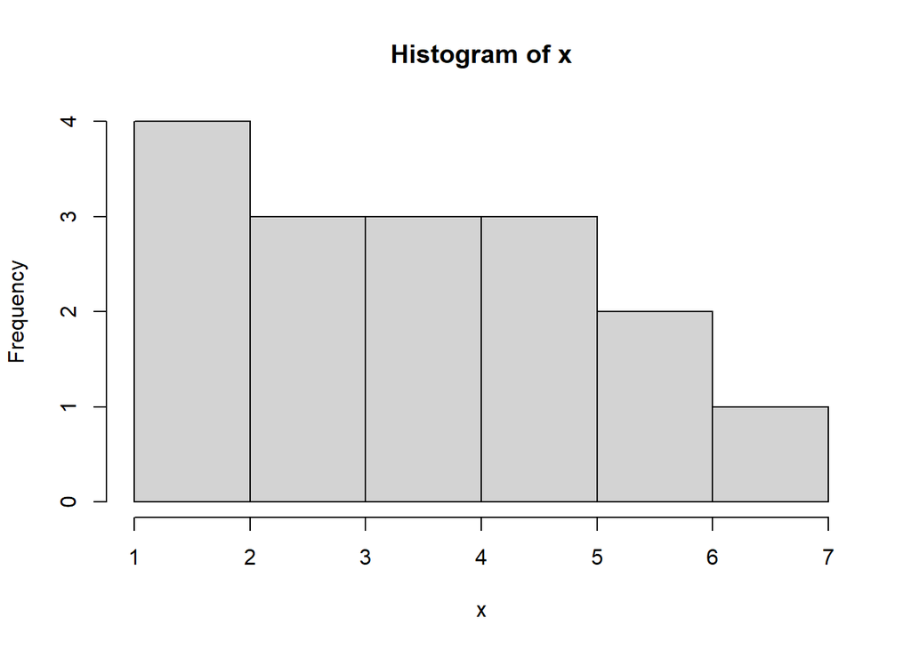

```r
x=c(1:5,3:7,1:6)
hist(x)
```

### 複選題

1.(BC)以下哪些函數是用來繪製類別資料統計圖?  
(A)hist() (B)pie() (C)barplot() (D)dotplot() (E)stem()  
2.(ADE)以下哪些函數是用來繪製數值資料統計圖?  
(A)hist() (B)pie() (C)barplot() (D)dotplot() (E)stem()

### 實作題

1.下載軟體包MASS並使用其中的數據框Cars93在1993年銷售部93汽車資料  
將其中的汽車類別變數Type轉換成為table變數並使用mfcol=c(1,2)繪圖參數設定在單張頁面中並排繪製一張直條圖(barplot)與另一張圓餅圖(pie)

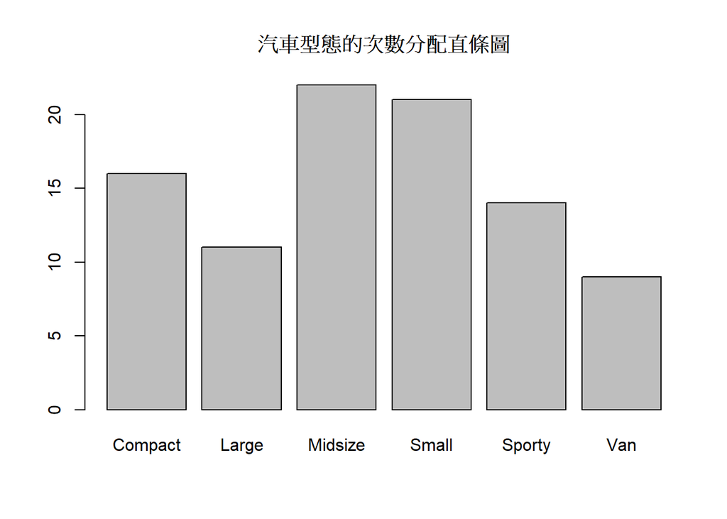

```r
#install.packages("MASS")
library(MASS)
car.table <- table(Cars93$Type)
barplot(car.table,main = "汽車型態的次數分配直條圖")
```

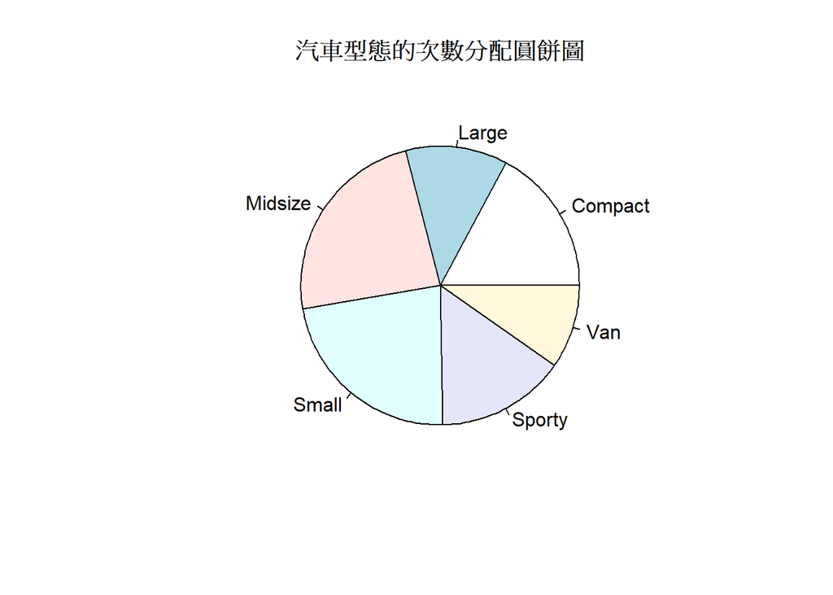

```r
pie(car.table,main = "汽車型態的次數分配圓餅圖")
```

2.下載軟體包MASS並使用其中的數據框Cars93在1993年銷售部93汽車資料  
使用兩個耗油量數值變數MPG.city與MPG.highway繪製散佈圖，並加上迴歸線與加註標題

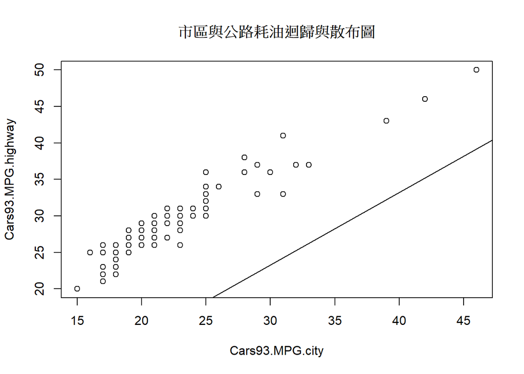

```r
#install.packages("MASS")
library(MASS)
car <- data.frame(Cars93$MPG.city,Cars93$MPG.highway)
model <- lm(Cars93.MPG.city~Cars93.MPG.highway,data = car)
model.value <- fitted(model)
plot(car,main = "市區與公路耗油迴歸與散布圖")
abline(model)
```